# Forecasting MSFT Stock Price Using Time Series Analysis

Below are the packages I used and can be loaded by the following:

```r
library(tidyverse)
library(lubridate)
library(forecast)
library(openblender)
```

The data that I used was from OpenBlender.io by using their package to import the data set.

I wanted the last 5 years of data. 2018 - Current date (Aug 12, 22). This was auto-generated code from their website.

```r
action <- "API_getObservationsFromDataset"

# ANCHOR: 'Microsoft Corporation Price'


parameters <- list(
  token="62f6b6d4951629199b2aabda3TbtwBMEsKMkZRzhvnaolC1U6n62Gg",
  id_user="62f6b6d4951629199b2aabda",
  id_dataset="5d4ca8709516290b01c9d725",
  date_filter = list(start_date="2018-01-01T08:00:00.000Z", end_date="2022-08-12"),
  add_time = list(treatment = "date")
)


df <- openblender::call(action, parameters)$sample
```

```
Task ID:  62f6ea8d0895fafb4a9d8d4b
Total estimated consumption:  500.11 processing units.
Task confirmed. Starting download...
Downloading...
Observations are being saved in 1660349069.07908.csv
0 %
50 %
100% completed.
Wrapping up, this may take a few minutes...
```

```r
head(df)
```

|  | change | high | low | open | price | timestamp | volume |
| --- | --- | --- | --- | --- | --- | --- | --- |
| 1 | -1.15% | 277.89 | 272.47 | 275.76 | 274.82 | 1659459600 | 22.01M |
| 2 | -0.91% | 281.28 | 275.85 | 277.46 | 278.01 | 1659373200 | 21.39M |
| 3 | 1.50% | 281.82 | 276.64 | 277.80 | 280.56 | 1659114000 | 31.71M |
| 4 | 2.85% | 277.83 | 268.00 | 269.83 | 276.41 | 1659027600 | 33.02M |
| 5 | 6.69% | 269.75 | 259.07 | 260.47 | 268.74 | 1658941200 | 45.65M |
| 6 | -2.68% | 259.57 | 249.57 | 259.57 | 251.90 | 1658854800 | 33.64M |

After importing the df, I wanted to change the ‘timestamp’ column to be in m/d/y format only for simplicity. Using the lubridate package, there are 2 functions that helped me get the result I wanted. “as_datetime” and “as_date”. There may be an easier way to do this next part but I didn’t care enough about scouring the web for answers. I just wanted it done. I created the column ‘datetime’ which transformed the “timestamp” format into “datetime” format. Then column ‘Date’ to transform the “datetime” format into date only.

|  | change | high | low | open | price | timestamp | volume | datetime | Date |
| --- | --- | --- | --- | --- | --- | --- | --- | --- | --- |
| 1 | -1.15% | 277.89 | 272.47 | 275.76 | 274.82 | 1659459600 | 22.01M | 2022-08-02 17:00:00 | 2022-08-02 |
| 2 | -0.91% | 281.28 | 275.85 | 277.46 | 278.01 | 1659373200 | 21.39M | 2022-08-01 17:00:00 | 2022-08-01 |
| 3 | 1.50% | 281.82 | 276.64 | 277.80 | 280.56 | 1659114000 | 31.71M | 2022-07-29 17:00:00 | 2022-07-29 |
| 4 | 2.85% | 277.83 | 268.00 | 269.83 | 276.41 | 1659027600 | 33.02M | 2022-07-28 17:00:00 | 2022-07-28 |
| 5 | 6.69% | 269.75 | 259.07 | 260.47 | 268.74 | 1658941200 | 45.65M | 2022-07-27 17:00:00 | 2022-07-27 |
| 6 | -2.68% | 259.57 | 249.57 | 259.57 | 251.90 | 1658854800 | 33.64M | 2022-07-26 17:00:00 | 2022-07-26 |

Once that was done I made a new df called ‘MSFT’ with all the original columns minus the ‘timestamp’ column and the ‘Date’ column to replace it.

|  | high | low | open | price | volume | Date |
| --- | --- | --- | --- | --- | --- | --- |
| 1172 | 86.31 | 85.50 | 86.12 | 85.95 | 22.48M | 2018-01-02 |
| 1171 | 86.51 | 85.97 | 86.06 | 86.35 | 26.06M | 2018-01-03 |
| 1170 | 87.66 | 86.57 | 86.59 | 87.11 | 21.91M | 2018-01-04 |
| 1169 | 88.41 | 87.43 | 87.66 | 88.19 | 23.41M | 2018-01-05 |
| 1168 | 88.58 | 87.60 | 88.20 | 88.28 | 22.11M | 2018-01-08 |
| 1167 | 88.73 | 87.86 | 88.65 | 88.22 | 19.48M | 2018-01-09 |

I created a test df to test the model that I will be making. Since I want to see the forecast for 60 days I narrowed the original ‘MSFT’ data to include data up to June 12, 2022 which was 2 months or 60 days ago.

```r
test.MSFT <- MSFT %>% filter(Date <= "2022-06-12")
head(test.MSFT)
```

|  | high | low | open | price | volume | Date |
| --- | --- | --- | --- | --- | --- | --- |
| 1 | 86.31 | 85.50 | 86.12 | 85.95 | 22.48M | 2018-01-02 |
| 2 | 86.51 | 85.97 | 86.06 | 86.35 | 26.06M | 2018-01-03 |
| 3 | 87.66 | 86.57 | 86.59 | 87.11 | 21.91M | 2018-01-04 |
| 4 | 88.41 | 87.43 | 87.66 | 88.19 | 23.41M | 2018-01-05 |
| 5 | 88.58 | 87.60 | 88.20 | 88.28 | 22.11M | 2018-01-08 |
| 6 | 88.73 | 87.86 | 88.65 | 88.22 | 19.48M | 2018-01-09 |

Since we filtered out the most recent 2 months. We need that data back so we can see how our model worked in comparison with actual price action. I slapped that back in using the same line of code but using a greater than sign.

```r
result.MSFT <- MSFT %>% filter(Date >= "2022-06-12")
head(result.MSFT)
```

|  | high | low | open | price | volume | Date |
| --- | --- | --- | --- | --- | --- | --- |
| 1 | 249.02 | 241.53 | 245.11 | 242.26 | 45.64M | 2022-06-13 |
| 2 | 245.74 | 241.51 | 243.86 | 244.49 | 28.29M | 2022-06-14 |
| 3 | 255.30 | 246.42 | 248.31 | 251.76 | 32.84M | 2022-06-15 |
| 4 | 247.35 | 243.03 | 245.78 | 244.97 | 32.67M | 2022-06-16 |
| 5 | 247.35 | 243.03 | 245.78 | 244.97 | 32.67M | 2022-06-16 |
| 6 | 250.50 | 244.03 | 244.70 | 247.65 | 42.43M | 2022-06-17 |

Lets begin making our Time Series using the ‘price’ column using the ts() function in R.

[figure not shown]

```r
test.MSFT.ts<- ts(test.MSFT$price, start = c(2018,1), frequency = 252)

plot(test.MSFT.ts)
```

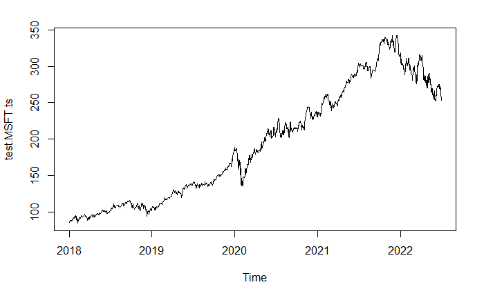

```r
test.MSFT <- test.MSFT[order(as.Date(test.MSFT$Date, format="%m/%d/%Y")),]

test.MSFT.ts<- ts(test.MSFT$price, start = c(2018,1), frequency = 252)

plot(test.MSFT.ts)
```

Now all is well in the world of this Time Series.

Okay, lets continue…

Using the ARIMA model I want to forecast the next 60 days of MSFT.I used the auto.arima() function since it seeks to identify the most optimal parameters and returns a fitted ARIMA model.

```r
tMSFT.arima <- auto.arima(test.MSFT.ts)

tMSFT.arima
```

```
Series: test.MSFT.ts
ARIMA(0,1,1) with drift

Coefficients:
          ma1   drift
      -0.0939  0.1481
s.e.   0.0304  0.0929

sigma^2 = 11.91:  log likelihood = -3007.53
AIC=6021.05   AICc=6021.08   BIC=6036.15
```

Now lets take a look at the residuals.

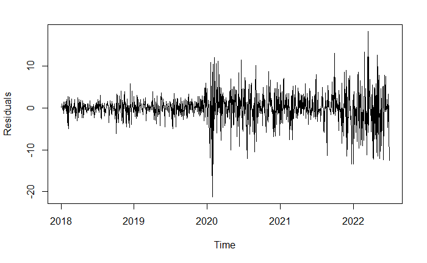

```r
plot(tMSFT.arima$residuals, ylab= "Residuals")
```

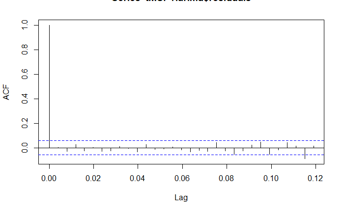

```r
acf(tMSFT.arima$residuals)
```

Now lets use the forecast function to help us see into the future.

```r
tMSFT.fc <- forecast(tMSFT.arima, 60)
head(tMSFT.fc)
```

```
$method
[1] "ARIMA(0,1,1) with drift"

$model
Series: test.MSFT.ts
ARIMA(0,1,1) with drift

Coefficients:
          ma1   drift
      -0.0939  0.1481
s.e.   0.0304  0.0929

sigma^2 = 11.91:  log likelihood = -3007.53
AIC=6021.05   AICc=6021.08   BIC=6036.15

$level
[1] 80 95

$mean
Time Series:
Start = c(2022, 126)
End = c(2022, 185)
Frequency = 252
 [1] 254.3128 254.4608 254.6089 254.7570 254.9050 255.0531 255.2012 255.3492 255.4973 255.6454 255.7934
[12] 255.9415 256.0896 256.2376 256.3857 256.5338 256.6818 256.8299 256.9779 257.1260 257.2741 257.4221
[23] 257.5702 257.7183 257.8663 258.0144 258.1625 258.3105 258.4586 258.6067 258.7547 258.9028 259.0509
[34] 259.1989 259.3470 259.4951 259.6431 259.7912 259.9392 260.0873 260.2354 260.3834 260.5315 260.6796
[45] 260.8276 260.9757 261.1238 261.2718 261.4199 261.5680 261.7160 261.8641 262.0122 262.1602 262.3083
[56] 262.4564 262.6044 262.7525 262.9005 263.0486

$lower
Time Series:
Start = c(2022, 126)
End = c(2022, 185)
Frequency = 252
              80%      95%
2022.496 249.8897 247.5482
2022.500 248.4922 245.3325
2022.504 247.4196 243.6138
2022.508 246.5261 242.1689
```

[output cut: 108 more lines]

```
2022.675 288.2213 302.6442
2022.679 288.6625 303.2406
2022.683 289.1007 303.8323
2022.687 289.5358 304.4195
2022.690 289.9681 305.0022
2022.694 290.3975 305.5806
2022.698 290.8242 306.1548
2022.702 291.2483 306.7249
2022.706 291.6697 307.2911
2022.710 292.0887 307.8535
2022.714 292.5052 308.4121
2022.718 292.9193 308.9671
2022.722 293.3312 309.5185
2022.726 293.7407 310.0665
2022.730 294.1481 310.6112
```

Lets test the accuracy of this model.

```r
accuracy(tMSFT.fc)
```

```
                       ME     RMSE      MAE         MPE     MAPE       MASE        ACF1
Training set 0.0006639959 3.446787 2.249325 -0.01157663 1.191191 0.03817775 0.002189908
```

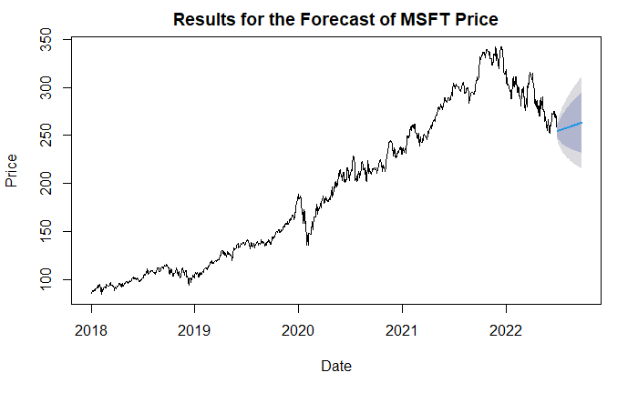

```r
plot(tMSFT.fc, xlab = "Date", ylab = "Price", main = "Results for the Forecast of MSFT Price")
```

Looks great!

Now lets see how it worked with the actual price action. We will add the results df that we made earlier back into this plot in red.

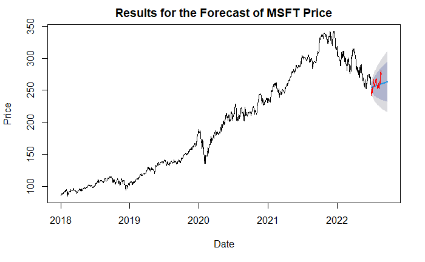

```r
plot(tMSFT.fc, xlab = "Date", ylab = "Price", main = "Results for the Forecast of MSFT Price")
lines(result.MSFT.ts, col="red")
```

If you got this far, I appreciate you sticking around and I hope that this was informative and exciting to see. I had a blast completing this analysis!

Thank you. - ALEX K.